# R Notebook

REML criterion at convergence: 15463.3

Scaled residuals: Min 1Q Median 3Q Max -3.6539 -0.4520 -0.1124 0.2857 10.4119

Correlation of Fixed Effects: (Intr) type.numerc -0.008 convergence code: 0 boundary (singular) fit: see ?isSingular

[output not shown]

boundary (singular) fit: see ?isSingular

[output not shown]

Linear mixed model fit by REML. t-tests use Satterthwaite’s method [‘lmerModLmerTest’] Formula: total_rt ~ type.numeric + (type.numeric || group) + (type.numeric || MD5) Data: .

REML criterion at convergence: 14928.6

Scaled residuals: Min 1Q Median 3Q Max -3.4626 -0.5024 -0.1218 0.2674 11.6959

Random effects: Groups Name Variance Std.Dev. MD5 type.numeric 0 0.00  
MD5.1 (Intercept) 75055 273.96  
group type.numeric 0 0.00  
group.1 (Intercept) 1447 38.04  
Residual 98831 314.37  
Number of obs: 1032, groups: MD5, 49; group, 24

Correlation of Fixed Effects: (Intr) type.numerc -0.010 convergence code: 0 boundary (singular) fit: see ?isSingular

[output not shown]

boundary (singular) fit: see ?isSingular

[output not shown]

Linear mixed model fit by REML. t-tests use Satterthwaite’s method [‘lmerModLmerTest’] Formula: total_rt ~ type.numeric + (type.numeric || group) + (type.numeric || MD5) Data: .

REML criterion at convergence: 14720.3

Scaled residuals: Min 1Q Median 3Q Max -2.3462 -0.3525 -0.1185 0.1593 18.1681

Fixed effects: Estimate Std. Error df t value Pr(>|t|)  
(Intercept) 811.20 39.51 45.20 20.532 <0.0000000000000002 *** type.numeric 26.14 13.91 20.62 1.879 0.0745 .  
— Signif. codes: 0 ‘**’ 0.001 ‘**’ 0.01 ‘’ 0.05 ‘.’ 0.1 ‘ ’ 1

Correlation of Fixed Effects: (Intr) type.numerc -0.010 convergence code: 0 boundary (singular) fit: see ?isSingular

[output not shown]

boundary (singular) fit: see ?isSingular

[output not shown]

Linear mixed model fit by REML. t-tests use Satterthwaite’s method [‘lmerModLmerTest’] Formula: total_rt ~ type.numeric + (type.numeric || group) + (type.numeric || MD5) Data: .

REML criterion at convergence: 14272.7

Scaled residuals: Min 1Q Median 3Q Max -2.7214 -0.4846 -0.1099 0.2504 9.1726

Random effects: Groups Name Variance Std.Dev. MD5 type.numeric 750.9 27.4  
MD5.1 (Intercept) 89566.0 299.3  
group type.numeric 0.0 0.0  
group.1 (Intercept) 18336.5 135.4  
Residual 103314.6 321.4  
Number of obs: 980, groups: MD5, 49; group, 24

Fixed effects: Estimate Std. Error df t value Pr(>|t|)  
(Intercept) 986.823 52.171 59.604 18.915 <0.0000000000000002 *** type.numeric 3.942 11.128 40.626 0.354 0.725  
— Signif. codes: 0 ‘**’ 0.001 ‘**’ 0.01 ‘’ 0.05 ‘.’ 0.1 ‘ ’ 1

Correlation of Fixed Effects: (Intr) type.numerc -0.007 convergence code: 0 boundary (singular) fit: see ?isSingular

[output not shown]

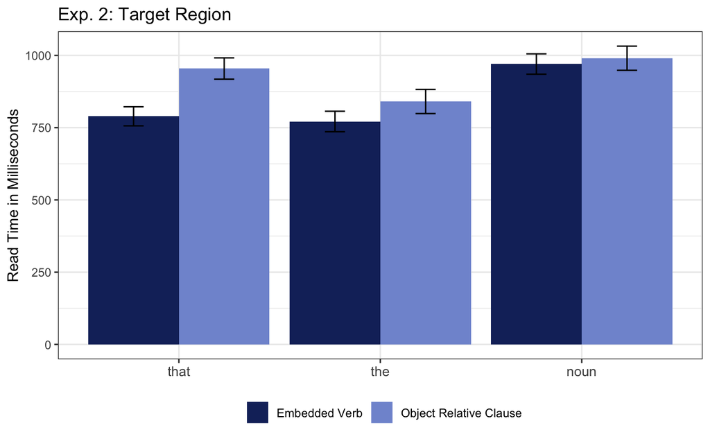

```r
#ggsave("../images/cogsci/target_exp2.pdf", width = 4, height = 3.5, device = "pdf")
```